# Graficar en R (bias genético)

### Cambiar el tipo de árbol

**Ejercicio** Revisa la ayuda de `plot.phylo` y utiliza un argumento de dicha función para graficar el árbol simulado pero que se vea como un abanico y luego como un cladograma (así):

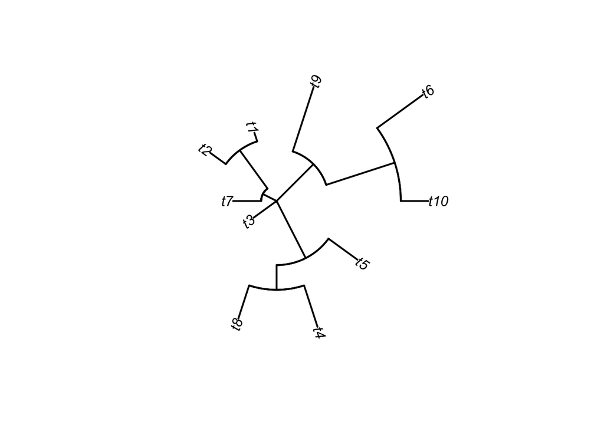

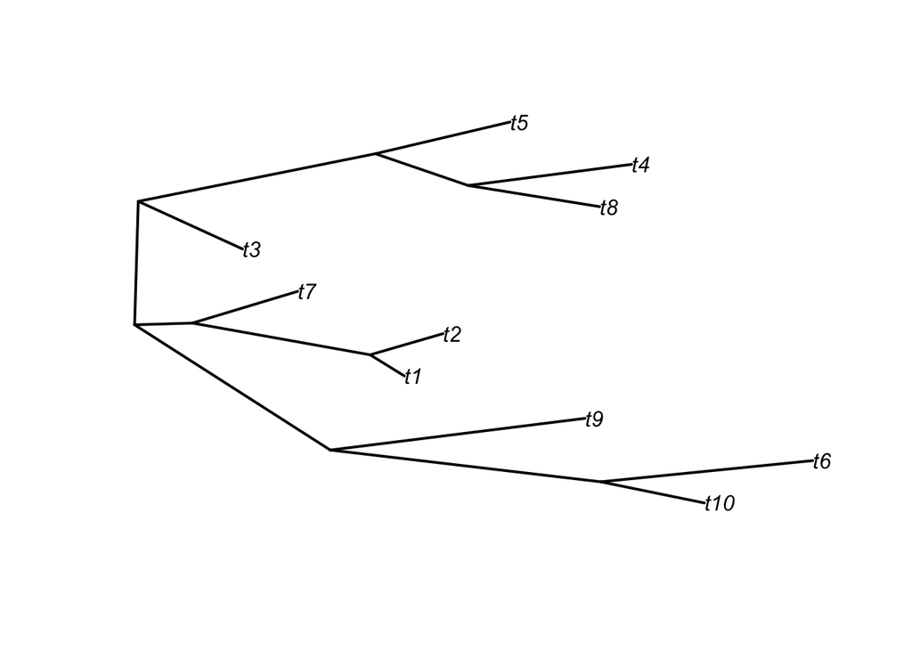

### Enraizar el árbol

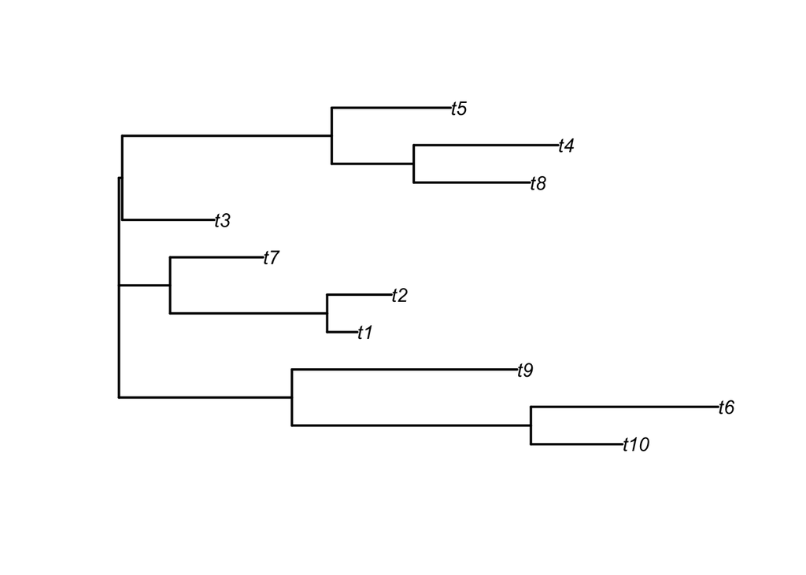

```r
# plot árbol sin enraizar
plot.phylo(tree, edge.width=2)
```

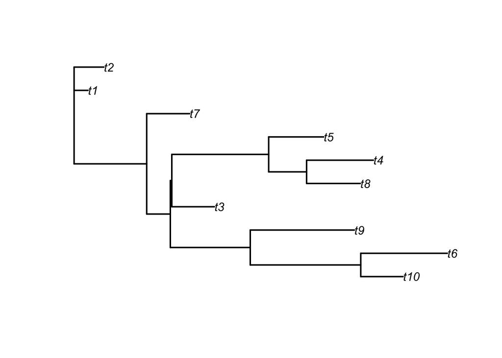

```r
# especificar output para enraizar:
tree<-root(tree, outgroup="t2")

# plot árbol enraizado
plot.phylo(tree, edge.width=2)
```

### Chulear el árbol

**Ejercicio:** Sigue los ejemplos de [Phylogenetic trees in R, del blog Sensory Evolution](https://ecomorph.wordpress.com/2014/10/09/phylogenetic-trees-in-r-4/) para realizar los siguientes cambios al árbol anterior:

- Cambia el nombre de las puntas de “t1”, “t2” etc a “especie 1”, “especie 2”, etc y asegúrate de graficar estos nombres en las puntas de tu árbol
- Agrega un círculo en los nombres de las puntas. El clado de las puntas t9, t6 y t 10 debe tener círculos rosas, la punta t2 gris y el resto verdes.
- Incremente al grosor de la línea
- Cambia el color de la línea a verde oscuro

### Leer un árbol en R y graficarlo

```r
# cargar archivo
maiz.tree<-read.nexus("PracUni3/maices/data/tree")

# checar contenido
maiz.tree
```

```
##
## Phylogenetic tree with 165 tips and 163 internal nodes.
##
## Tip labels:
##  maiz_3, maiz_68, maiz_91, maiz_39, maiz_12, maiz_41, ...
##
## Unrooted; includes branch lengths.
```

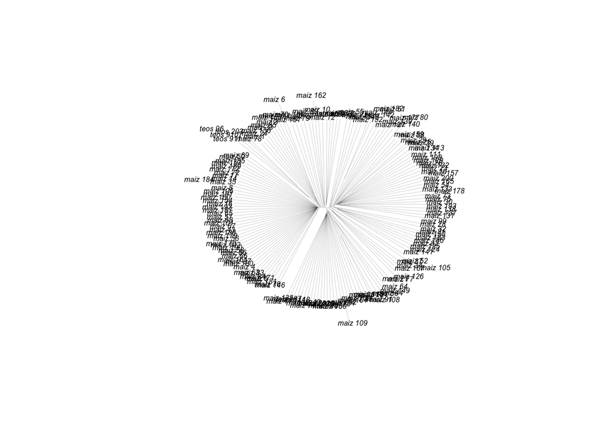

```r
# graficar
plot(maiz.tree, type="unrooted", edge.width=0.1, cex=0.5)
```

Vamos a poner colores de acuerdo a la Categoría de Altitud en vez de nombres de muestras.

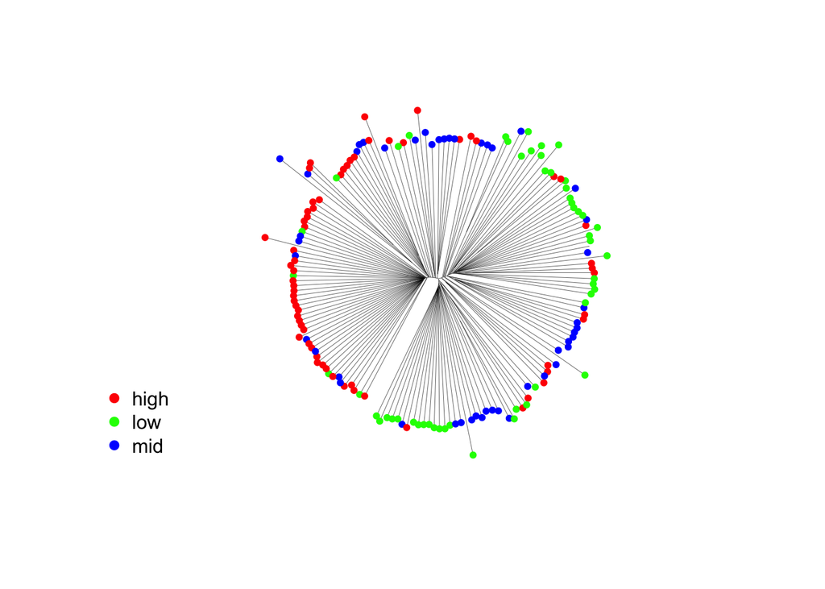

```r
### Graficar por Categorías Altitud

# leer info extra de las muestras
fullmat<-read.delim("PracUni3/maices/meta/maizteocintle_SNP50k_meta_extended.txt")

# ¿Cuántos colores necesito?
numcolsneeded<-length(levels(fullmat$Categ.Altitud))
palette(rainbow(numcolsneeded))

# graficar sin nombres de muestras
plot(maiz.tree, type="unrooted", edge.width=0.3, show.tip=FALSE)

# Agregar tip labels que correspondan a las categorías de altitud
tiplabels(pch=20, col=fullmat$Categ.Altitud)
# legend
legend(x= "bottomleft", legend=levels(fullmat$Categ.Altitud), pch=19, col=1:numcolsneeded, cex=1, , bty="n")
```

**Ejercicio**: Colorea el árbol anterior por Raza (sin incluir una leyenda porque son demasiadas)

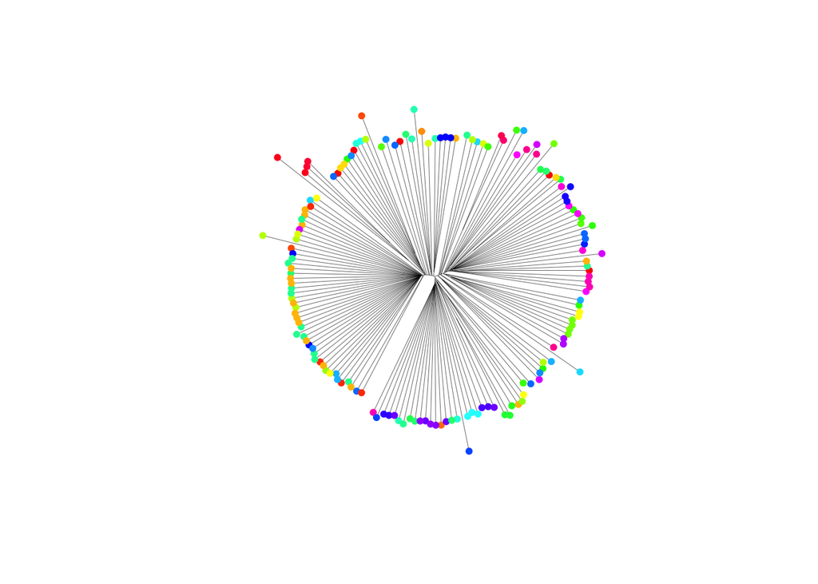

#### Árboles filogenéticos 2.1

Los árboles filogenéticos también pueden graficarse estilo ggplot, con el paquete de Biocounductor [ggtree](https://bioconductor.org/packages/release/bioc/html/ggtree.html), que veremos más adelante junto con otros paquetes.